# Taller RMarkdown - Academia OSL Ciencia de Datos

Paulo Villarroel

junio 2021

# 1 R Markdown

Este es un archivo de tipo *R Markdown* (`.Rmd`), en este tipo de archivos podemos de manera simple intercalar texto con código. Ojo, que para insertar un párrafo es necesario saltarse 1 línea.

Estes es otro párrafo.

Para hacer un salto de línea, es necesario poner 2 espaciones al final.  
Salto de línea.

El código se define en los “pedazos de código” (*code chunks*):

```r
# Una suma por ejemplo
2 + 2
```

```
## [1] 4
```

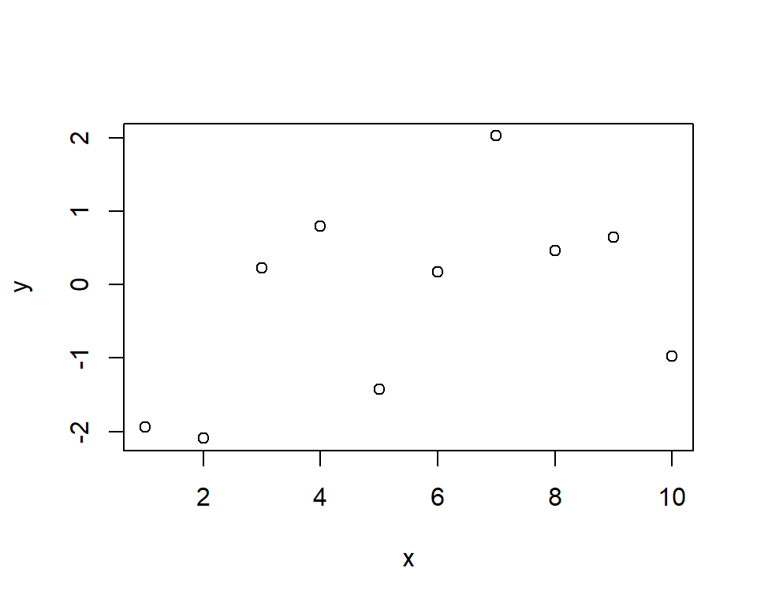

```r
# o un gráfico simple
x <- 1:10
y <- rnorm(10)
plot(x, y)
```

Y estos “pedazos de código” tienen distintas opciones que por ejemplos nos permiten solo motrar el resultado y no el código que lo genera (`echo = FALSE`):

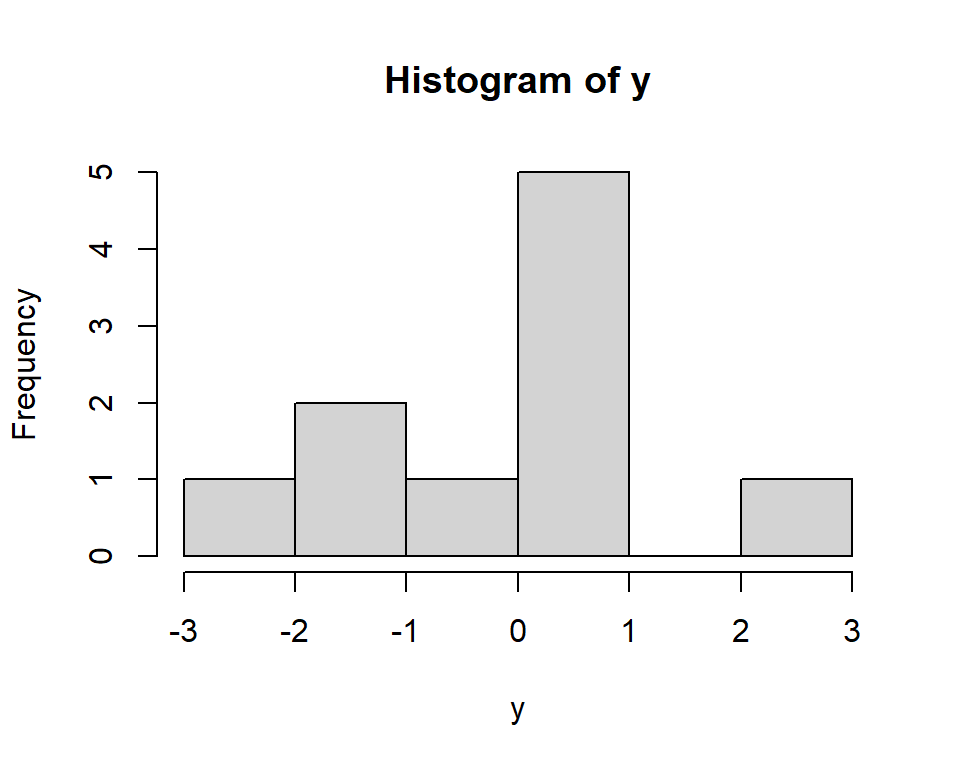

# 2 Formato de texto

Así como hay formas de manipular el código que trabajemos existe también una gran variedad de opciones para dar formato al texto que queramos incluir en un documento:

- *cursiva*
- **negrita**
- *cursiva y negrita*
- tachado
- [link](https://gobierno.uai.cl/centro-investigacion/goblab-uai/)
- `Objetos de código`
- entre otras..

También podemos definir distintos niveles de jerarquía respecto a títulos y subtítulos

# 3 Título 1 (`# Título 1`)

## 3.1 Título 2 (`## Título 2`)

### 3.1.1 Título 3 (`### Título 3`)

#### 3.1.1.1 Título 4 (`#### Título 4`)

##### 3.1.1.1.1 Título 5 (`##### Título 5`)

###### 3.1.1.1.1.1 Título 6 (`###### Título 6`)

Por otro lado, este tipo de archivo también nos facilita escribir formulas/operaciones/objetos matemáticos (con sintáxis $\LaTeX$) tanto en linea con el texto ($\sum_{i=1}^n X_i$) como en su propio párrafo:

$$\int_0^{2\pi} \sin x~dx$$

$$\mathbf{X} = \left[\begin{array}
{rrr}
1 & 2 & 3 \\
4 & 5 & 6 \\
7 & 8 & 9
\end{array}\right]$$

También se pueden incluir links: Web de [OpenSalud LAB](http://www.opensaludlab.org)